# ESM 204 - Assignment 4

Conner Smith and Taylor Gries

5/18/2022

## Overview

```r
# Read in the main data sets

damages <- read_csv(here("data", "damages.csv")) %>%
  clean_names()

warming <- read_csv(here("data", "warming.csv")) %>%
  clean_names() %>%
  select(-x1)
```

The federal government uses a variety of measures to estimate the SCC to quantify the costs associated with climate change. This analysis considers several discount rate calculation methods and reports differences in damages based on different warming and policy scenarios.

## **Analysis**

The dataset contains the following:

- Climate change damages measured in USD based on warming increases in Degrees Celsius “high” and “low.”
- Two warming scenarios (in Celsius) based on a “baseline” and “pulse” scenario with higher warming in the “pulse” scenario.

### **1. Damage Equation**

This section generates a quadratic damage function relating the dollar value of damages to the change in global mean temperature.

```r
# Estimate a function with 0 intercept, take a look at the data first

#ggplot(data = damages, aes(x = warming, y = damages)) +
  #geom_point()

# This is clearly exponential, create a vector of the warming values squared

#Creating a scaled dataset scaled to billions

damages_scale <- damages %>%
  mutate(damages = damages/1000000000)

warming_square <- damages_scale$warming^2

# now we regress, force the itnercept to 0

damage_model <- lm(damages ~ 0 + warming + warming_square, data = damages_scale)
#summary(damage_model)
# This gives us an R^2 of 99%, we're good

# summary essentially gives us that damages = 19409275730643(warming_square) -1059530137756(warming)
# Lets see if this makes sense when predicting

warming_range <- damages$warming
damage_predict <- predict(damage_model,list(warming = warming_range, warming2 = warming_range^2))

# Create a function of the equation

damage_function <- function(x){
  damage_model$coefficients[1]*x+damage_model$coefficients[2]*x^2
}
```

#### **Figure 1: Damages Resulting from Climate Change**

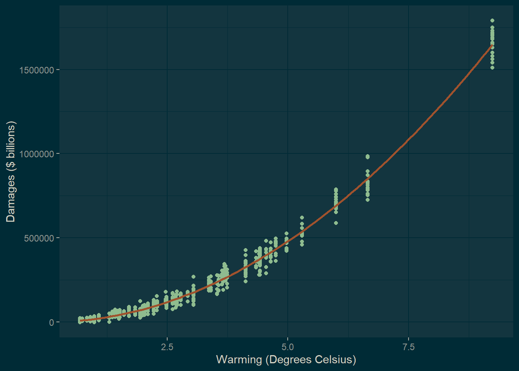

```r
# Plot the function along with the underlying data


ggplot(data = damages_scale, aes(x = warming, y = damages)) +
  geom_point(color = 'darkseagreen') +
  geom_smooth(aes(x = warming_range, y = damage_predict), color = 'sienna') +
  labs(x = 'Warming (Degrees Celsius)', y = 'Damages ($ billions)')
```

```r
#Looks good enough to me, note the Y axis now shows damages in billions of dollars
```

### **2. Damage Calculations**

This section uses the function generated from the damages data to predict damages in each year under the baseline climate and the pulse scenario.

#### **Figure 2: Damages Over Time With and Without the “Pulse” Scenario**

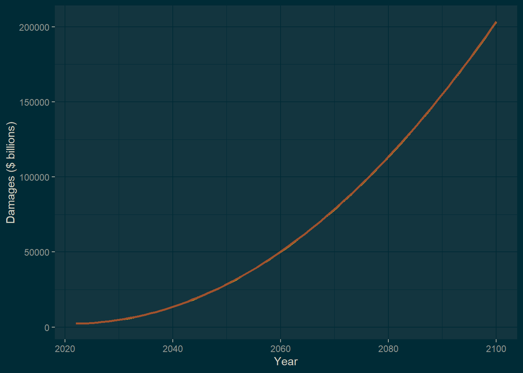

```r
# Generate the estimates and facet wrap a plot showing the impacts of the two scenarios side by side

#divide difference by 35 billion to get the effect per ton, note we already scaled to billions

pulse_ton <- 35

damages_predict <- warming %>%
  mutate(damages_baseline = damage_function(warming_baseline)) %>%
  mutate(damages_pulse = damage_function(warming_pulse)) %>%
  mutate(damages_difference = damages_pulse - damages_baseline) %>%
  mutate(damages_difference_ton = damages_difference/pulse_ton)

# Create the first graph showing the lines for both scenarios and total damages

ggplot(data = damages_predict, aes(x = year)) +
  geom_smooth(aes(y = damages_baseline), color = "goldenrod") +
  geom_smooth(aes(y = damages_pulse), color = "sienna") +
  labs(x = 'Year', y = 'Damages ($ billions)')
```

*Note: the difference in damages between the two scenarios appear relatively small and the “pulse scenario” (red line) is only marginally higher than the “baseline” scenario (yellow line) which is barely visible given the scale of this graph.*

#### **Figure 3: Difference in Absolute and Per Ton Damages Over Time Between Scenarios**

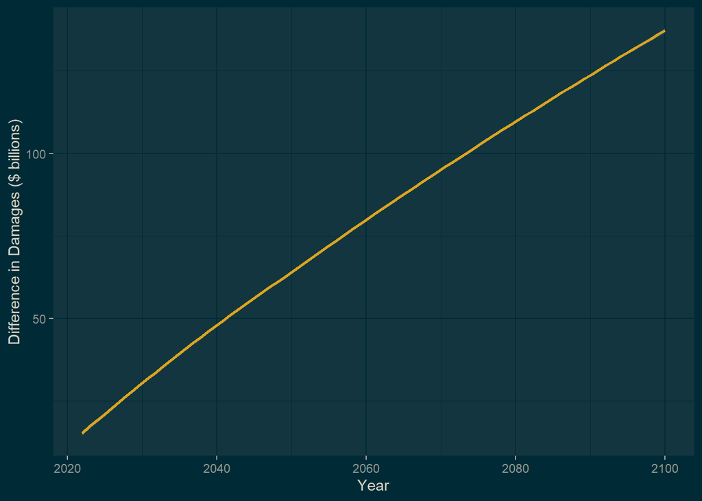

```r
# Generate the differences and facet wrap two plots showing absolute difference between the two scenarios and the difference per ton of CO2

absolute_plot <- ggplot(data = damages_predict,
                        aes(x = year, y = damages_difference)) +
  geom_smooth(color = "goldenrod") +
  labs(x = 'Year', y = 'Difference in Damages ($ billions)')
absolute_plot
```

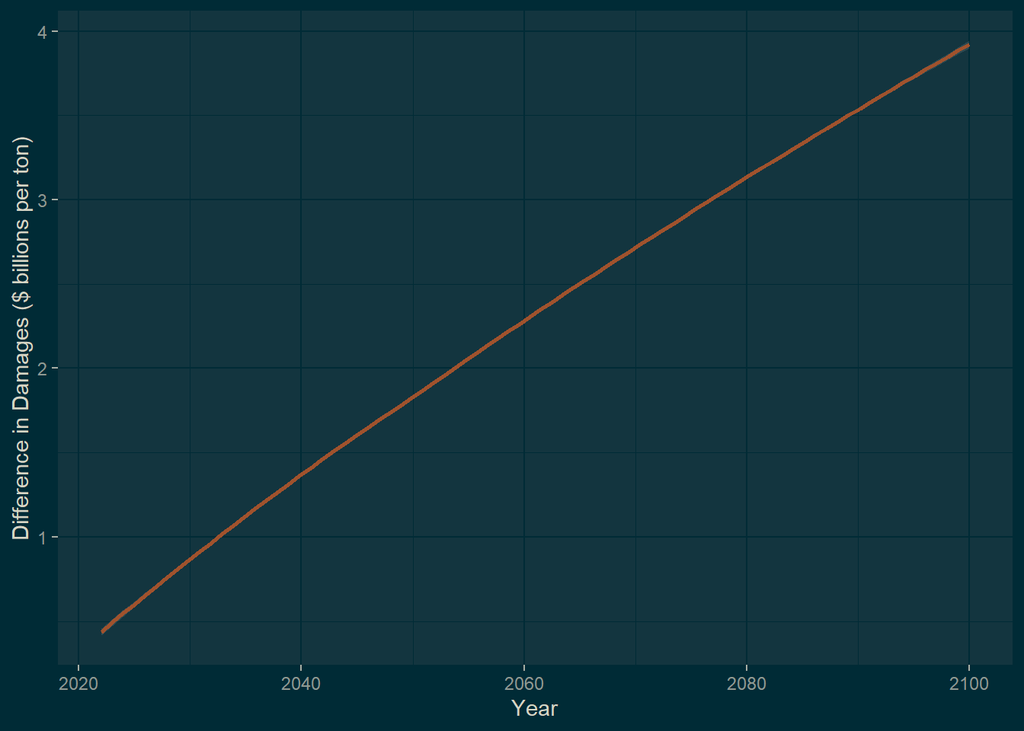

```r
ton_plot <- ggplot(data = damages_predict,
                        aes(x = year, y = damages_difference_ton)) +
  geom_smooth(color = "sienna") +
  labs(x = 'Year', y = 'Difference in Damages ($ billions per ton)')
ton_plot
```

```r
# may need to double check units/conversion here but the graphs look okay
```

### **3. SCC Analysis**

This section uses different discount rates to estimate a range of potential SCC values.

#### **Figure 4: Discount Rate Impacts on SCC**

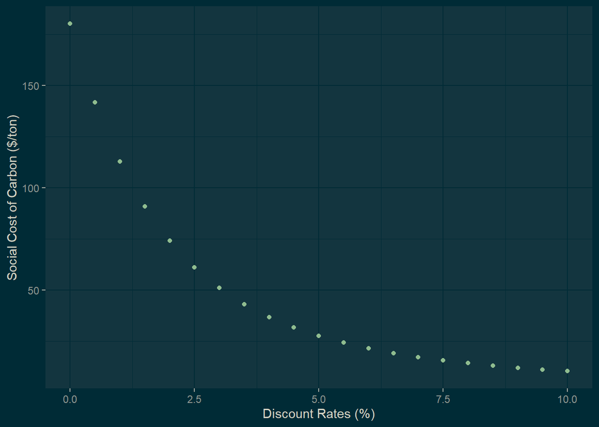

```r
# Plot a range of discount rates (likely 2-10 percent) to estimate SCC values

# Calculate net damages up to 2100 from one tonne of CO2 by summing damages_difference_ton

net_damages_per_ton <- sum(damages_predict$damages_difference_ton)

# Create a function of net present value using the discount rate, damage, time, and present time

discount_damages <- function(rate, damage, time, present_time){
  NPV <- damage/ (1 + (rate/100))^(time-present_time)
  return(NPV)
}

# Create data frame for discounting

discount <- data_frame(rates = seq(0,10, 0.5), SCC = seq(0,10, 0.5))

# Use for loop to calculate the discounted damages up to 2100 for discount rates from 0 to 10 and apply function to sum all elements in column to find the net discounted cost

for(x in 1:length(discount$rates)){
  discount$SCC[x] <- sum(discount_damages(discount$rates[x], damages_predict$damages_difference_ton, damages_predict$year, 2022))
}

# Plot discount

ggplot(data = discount) +
  geom_point(aes(x = rates, y = SCC), color = "darkseagreen") +
  labs (x = "Discount Rates (%)", y = "Social Cost of Carbon ($/ton)")
```

*Figure 4 shows that increasing the discount rate lowers the SCC.*

### **4. Ramsey Rule**

This section uses the following function to estimate the SCC:

$$\begin{equation}
r=p+ng
\end{equation}$$

#### **Figure 5: SCC in Relation to Ramsey Rule**

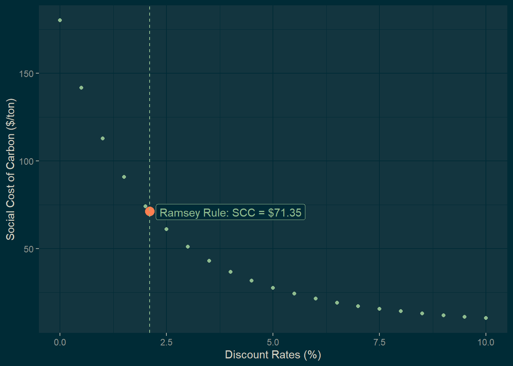

```r
# Using ρ = 0.001, η = 2, and g = 0.01, what is the SCC, find it on the graph above

# define the values
p <- 0.001
n <- 2
g <- 0.01

# plug into the Ramsey rule

ramsey <- (p+n*g)*100

# plug into previous equation

discount_ramsey <- sum(discount_damages(ramsey,damages_predict$damages_difference_ton, damages_predict$year, 2022))

# SCC is $71.35 using the Ramsey Rule

ggplot(data = discount)+
  geom_point(aes(x = rates, y = SCC), color = "darkseagreen")+
  geom_point(x = ramsey, y = discount_ramsey, color = "coral", size = 4) +
  geom_vline(xintercept = 2.1, color = 'darkseagreen', linetype = "dashed") +
  geom_label(aes(x = 4, label = "Ramsey Rule: SCC = $71.35",
                 y = 71), color = "darkseagreen", angle = 90) +
  labs(x = "Discount Rates (%)", y = "Social Cost of Carbon ($/ton)")
```

The parameters used in this calculation were ρ = 0.001, η = 2, and g = 0.01. This gives an SCC value of $71.35/ton. This SCC level is consistent with the discount rates proposed by the Obama administration and New York State.

### **5. Policy Considerations**

This section will consider business as usual (Policy A) against strong action against climate change (Policy B). Conditions are as follows:

- **Policy A:** Warming will occur as in the “baseline” (i.e. “no-pulse”) dataset above (this happens with probability 0.5) or warming each year will be 1.5 times that in the “baseline” dataset (with probability 0.5).
- **Policy B:** Warming will continue until 2050 as in the “baseline” dataset, and then will stabilize at 1.29 degrees and stay that way forever.

```r
# Estimate PV for the Policy A scenario, discount rate is 2%
discount_policy <- 2

# Need to create a new dataset with the damages and PV for both baseline and 1.5X warming

damages_policy_a <- damages_predict %>%
  select(year, warming_baseline, damages_baseline) %>%
  mutate(damages_1.5 = damage_function(1.5*warming_baseline)) %>%
  mutate(pv_baseline =
           discount_damages(discount_policy, damages_baseline,
                            damages_predict$year, 2022)) %>%
  mutate(pv_1.5 = discount_damages(discount_policy, damages_1.5,
                            damages_predict$year, 2022))

# Now we need to calculate the probabilities.

prob_base <- 0.5
prob_1.5 <- 0.5

# Sum the pv for each
sum_base <- sum(damages_policy_a$pv_baseline)
sum_1.5 <- sum(damages_policy_a$pv_1.5)

# Scale these by probability
expected_value_a <- (sum_base * prob_base) + (sum_1.5 * prob_1.5)
#3023245 billion dollars (I think) CHECK THIS NUMBER

# Now do this for policy B
damages_policy_b <- damages_predict %>%
  select(year, warming_baseline)

for (i in 30:79){
  damages_policy_b$warming_baseline[i]=1.29
}

# Warming locked at 1.29 after 2050

damages_policy_b <- damages_policy_b %>%
  mutate(damages_b = damage_function(warming_baseline)) %>%
  mutate(pv_b =
           discount_damages(discount_policy, damages_b,
                            damages_predict$year, 2022))

prob_b <- 1
sum_b <- sum(damages_policy_b$pv_b)
expected_value_b <- (sum_b * prob_b)
```

- **A: Present Value of Damages under Policy A =** $3023246 billion
- **B: Present Value of Damages under Policy B =** $786671 billion

*Assume: Society is risk neutral and the discount rate is 2%. Policy A costs $0 and Policy B costs $X to implement. Total cost is implementation cost + damages.*

#### **Figure 6: Total Cost by Policy Pathway**

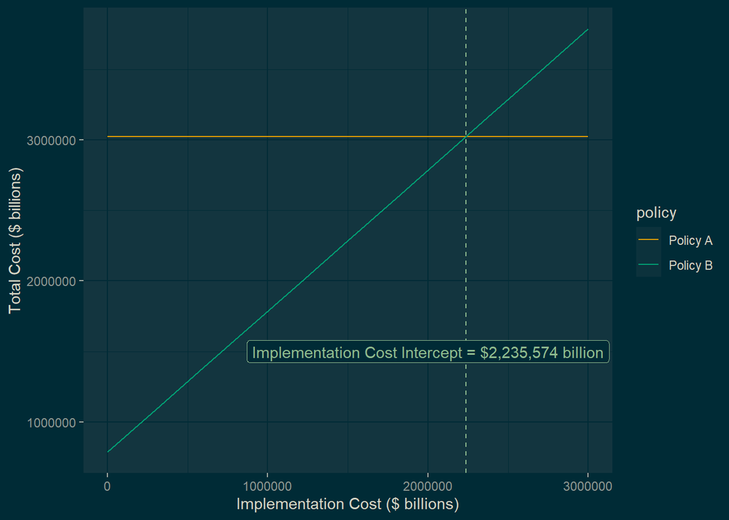

```r
# Now we need the total cost

# Cost to implement A is just the expected PV of the damages
cost_a <- function(x){expected_value_a}

# B adds in the implementation cost (X)
cost_b <- function(x){expected_value_b + x}

# For the cost of b to equal the cost of a, implementation cost would have to be $2236574 billion:

x_equal <- expected_value_a - expected_value_b


# Now create a new data frame, including a vector of possible costs (in billions) based on difference calcualted above
cost <- c(0,3e5,6e5,9e5,12e5,15e5,18e5,21e5,24e5,27e5,30e5)

cost_df <- data.frame(cost) %>%
  mutate(cost_a = cost_a(cost)) %>%
  mutate(cost_b = cost_b(cost)) %>%
  pivot_longer(cols = c(cost_a, cost_b),
               names_to = 'policy', values_to = 'total_cost') %>%
  mutate(policy = case_when(policy == "cost_a" ~ "Policy A",
                            policy == "cost_b" ~ "Policy B"))

ggplot(data = cost_df, aes(x = cost, y = total_cost)) +
  geom_line(aes(color = policy)) +
  geom_vline(xintercept = x_equal, color = 'darkseagreen', linetype = "dashed") +
  geom_label(aes(x = 2000000,
                 label = "Implementation Cost Intercept = $2,235,574 billion",
                 y = 1500000), color = "darkseagreen", angle = 90) +
  labs(x = "Implementation Cost ($ billions)", y = "Total Cost ($ billions)")
```

**Takeaway:** Congress should adopt **Policy B** unless implementation costs are greater than $2236574 billion. Otherwise, they should adopt Policy A *assuming decisions are made to minimize cost and that total cost of Policy A is the present value of damages through 2100 and total cost of Policy B is the sum of the implementation cost and the present value of those damages through 2100.*

### **6. Risk Averse**

The more risk averse society is, the more attractive Policy B becomes. The point where Policy B and Policy A have the same total cost (in other words, the level of implementation cost that creates this scenario) would increase. This is because the costs and risks of Policy B are known, the probability of achieving these costs is 1. On the other hand, the costs of Policy A are unknown. There is a 50% chance warming will follow the baseline and deliver lower costs. But there is also the risk (50% chance) that warming will be 1.5 times higher and drive the cost of damage up.

**To avoid the risk of falling into this higher damage scenario, Congress should prioritize Policy B if we are assuming risk aversion is leading the decision-making process.**